# Prediction of Sales Prices of Houses

## Performing Ridge Regression

```r
ridgefit <- glmnet(xtrain,ytrain, alpha=0, lambda = lambda.array)
summary(ridgefit)
```

```
##           Length Class     Mode
## a0         10000 -none-    numeric
## beta      110000 dgCMatrix S4
## df         10000 -none-    numeric
## dim            2 -none-    numeric
## lambda     10000 -none-    numeric
## dev.ratio  10000 -none-    numeric
## nulldev        1 -none-    numeric
## npasses        1 -none-    numeric
## jerr           1 -none-    numeric
## offset         1 -none-    logical
## call           5 -none-    call
## nobs           1 -none-    numeric
```

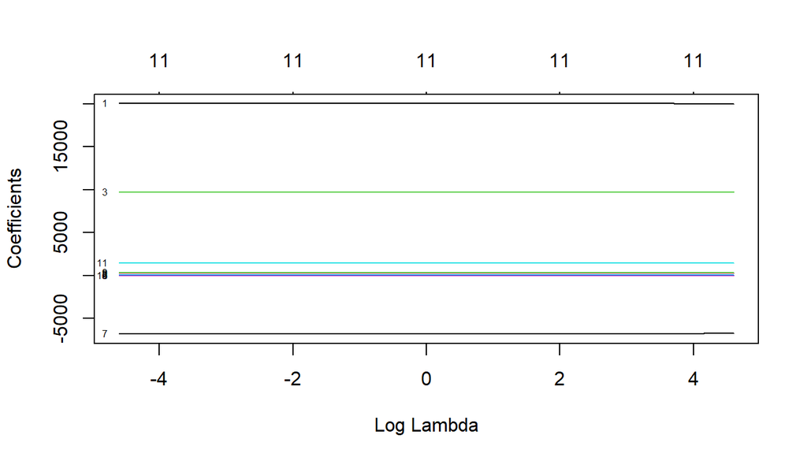

```r
plot(ridgefit, xvar= 'lambda', label = T)
```

### Predicted values:Ridge Regression:Model3

```r
y_predicted <- predict(ridgefit,s=min(lambda.array),newx = as.matrix(xtest))
```

### Co-efficients

```r
predict(ridgefit, s=min(lambda.array), newx = xtest, type = 'coefficients')
```

```
## 12 x 1 sparse Matrix of class "dgCMatrix"
##                             s1
## (Intercept)     -1212760.50470
## df.OverallQual     20022.58508
## df.GrLivArea          43.05133
## df.GarageCars       9715.19652
## df.GarageArea         14.09776
## df.TotalBsmtSF        15.77075
## df.X1stFlrSF          16.31464
## df.FullBath        -6806.65978
## df.YearBuilt         247.58805
## df.YearRemodAdd      330.74997
## df.MasVnrArea         26.91357
## df.TotRmsAbvGrd     1450.15173
```

### R-Square:Ridge Regression:Model3

```r
sst <- sum((ytest - mean(ytest))^2)
sse <- sum((y_predicted - ytest)^2)

rsquare_ridge <- 1-(sse/sst)
rsquare_ridge
```

```
## [1] 0.8349414
```

```r
rsquare_ridge_1 <- rsquare_ridge
```

### Adjusted R-Square:Ridge Regression:Model3

```r
n <- nrow(as.matrix(ytest))
p <- 11

arsquare_ridge <- (1-((1-rsquare_ridge)*(n-1)/(n-p-1)))
arsquare_ridge
```

```
## [1] 0.8284569
```

### MSE:Ridge Regression:Model3

```r
MSE_ridge = (sum((y_predicted - ytest)^2) / length(y_predicted))
MSE_ridge
```

```
## [1] 1046008518
```

### RMSE:Ridge Regression:Model3

```r
rmse_ridge <- sqrt(MSE_ridge)
rmse_ridge
```

```
## [1] 32342.05
```

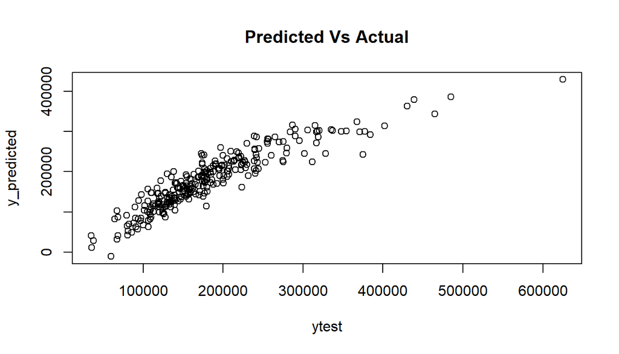

```r
plot(ytest, y_predicted, main ='Predicted Vs Actual')
```

### MAE:Ridge Regression:Model3

```r
mae(ytest,y_predicted)
```

```
## [1] 22919.28
```

#### Ridge model 3 has a:

#### MAE= 22919.28

#### MSE= 1046008518

#### RMSE = 32342.05

#### Rsquare = 0.8349414

#### Adj Rsquare = 0.8284569

## Performing LASSO Regression

```r
lassofit <- glmnet(xtrain,ytrain, alpha =1, lambda = lambda.array)
summary(lassofit)
```

```
##           Length Class     Mode
## a0         10000 -none-    numeric
## beta      110000 dgCMatrix S4
## df         10000 -none-    numeric
## dim            2 -none-    numeric
## lambda     10000 -none-    numeric
## dev.ratio  10000 -none-    numeric
## nulldev        1 -none-    numeric
## npasses        1 -none-    numeric
## jerr           1 -none-    numeric
## offset         1 -none-    logical
## call           5 -none-    call
## nobs           1 -none-    numeric
```

### Lambdas in relation to coefficients

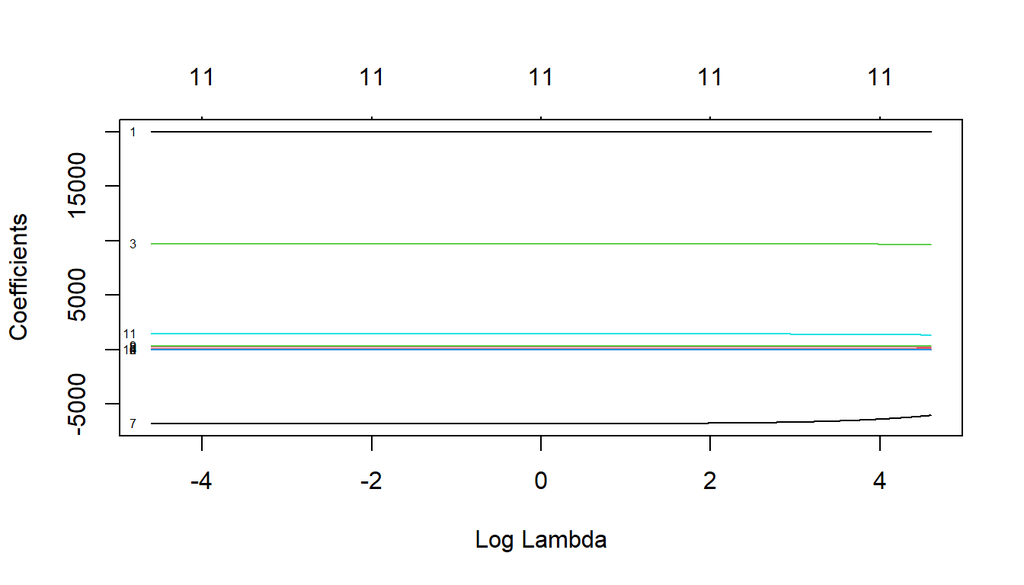

```r
plot(lassofit,xvar = 'lambda',label=T)
```

### Predicted values

```r
y_predicted_lasso <- predict(lassofit, s=min(lambda.array), newx = as.matrix(xtest))
```

### R-Square:LASSO Regression:Model3

```r
sst <- sum((ytest - mean(ytest))^2)
sse <- sum((y_predicted_lasso - ytest)^2)

rsquare_lasso <- 1-(sse/sst)
rsquare_lasso
```

```
## [1] 0.8349414
```

### Adjusted R-Square:LASSO Regression:Model3

```r
n <- nrow(as.matrix(ytest))
p <- 11

arsquare_lasso <- (1-((1-rsquare_lasso)*(n-1)/(n-p-1)))
arsquare_lasso
```

```
## [1] 0.8284569
```

### MSE:LASSO Regression:Model3

```r
MSE_lasso = (sum((y_predicted_lasso - ytest)^2) / length(y_predicted_lasso))
MSE_lasso
```

```
## [1] 1046008312
```

### RMSE:LASSO Regression:Model3

```r
rmse_lasso <- sqrt(MSE_lasso)
rmse_lasso
```

```
## [1] 32342.05
```

### MAE:LASSO Regression:Model3

```r
mae(ytest,y_predicted_lasso)
```

```
## [1] 22919.28
```

#### Lasso model 3 has a:

#### MAE= 22919.28

#### MSE= 1046008312

#### RMSE = 32342.05

#### Rsquare = 0.8349414

#### Adj Rsquare = 0.8284569

## Performing ElasticNet Regression

```r
elasticnetfit <- glmnet(xtrain,ytrain, alpha = 0.5, lambda = lambda.array)
summary(elasticnetfit)
```

```
##           Length Class     Mode
## a0         10000 -none-    numeric
## beta      110000 dgCMatrix S4
## df         10000 -none-    numeric
## dim            2 -none-    numeric
## lambda     10000 -none-    numeric
## dev.ratio  10000 -none-    numeric
## nulldev        1 -none-    numeric
## npasses        1 -none-    numeric
## jerr           1 -none-    numeric
## offset         1 -none-    logical
## call           5 -none-    call
## nobs           1 -none-    numeric
```

### Lambdas in relation to coefficients

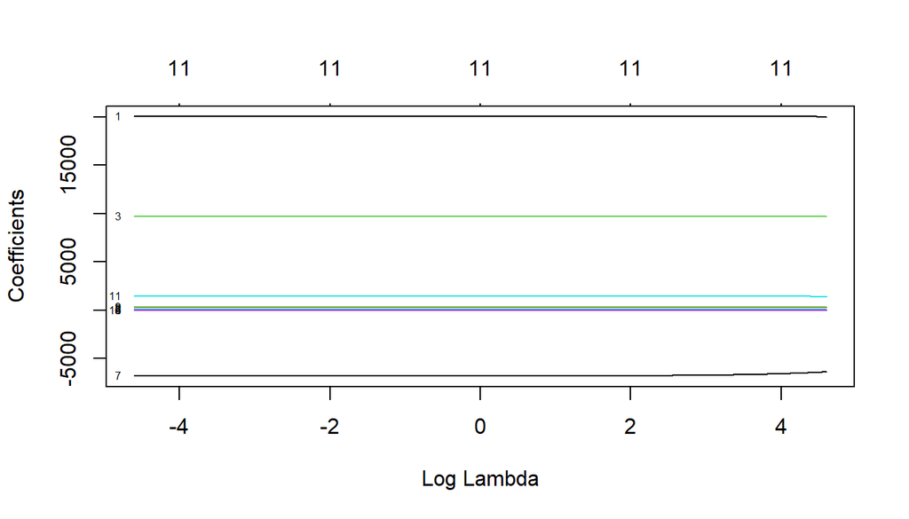

```r
plot(elasticnetfit,xvar = 'lambda',label=T)
```

### Predicted values:ELASTIC NET Regression:Model3

```r
y_predicted_elasticnet <- predict(elasticnetfit, s=min(lambda.array), newx = as.matrix(xtest))
```

### R-Square:ELASTIC NET Regression:Model3

```r
sst <- sum((ytest - mean(ytest))^2)
sse <- sum((y_predicted_elasticnet - ytest)^2)

rsquare_elasticnet <- 1-(sse/sst)
rsquare_elasticnet
```

```
## [1] 0.8349414
```

### Adjusted R-Square:ELASTIC NET Regression:Model3

```r
n <- nrow(as.matrix(ytest))
p <- 11

arsquare_elasticnet <- (1-((1-rsquare_elasticnet)*(n-1)/(n-p-1)))
arsquare_elasticnet
```

```
## [1] 0.8284569
```

### MSE:ELASTIC NET Regression:Model3

```r
MSE_elasticnet = (sum((y_predicted_elasticnet - ytest)^2) / length(y_predicted_elasticnet))
MSE_elasticnet
```

```
## [1] 1046008427
```

### RMSE:ELASTIC NET Regression:Model3

```r
rmse_elasticnet <- sqrt(MSE_elasticnet)
rmse_elasticnet
```

```
## [1] 32342.05
```

### MAE:ELASTIC NET Regression:Model3

```r
mae(ytest,y_predicted_elasticnet)
```

```
## [1] 22919.28
```

#### Elastic Net model 3 has a:

#### MAE= 22919.28

#### MSE= 1046008427

#### RMSE = 32342.05

#### Rsquare = 0.8349414

#### Adj Rsquare = 0.8284569

### Printing the Evaluation metrics for different models

```r
model1 <- read.csv("D:\\COllege\\5th sem\\CSE3505\\Project\\Model1.csv")
model1
```

```
##   Sr.No Regression  R.Square Adjusted.R.Square        MSE     RMSE      MAE
## 1     1      Ridge 0.8167762         0.8129188 1161124706 34075.28 24183.42
## 2     2      Lasso 0.8167762         0.8129188 1161124748 34075.28 24183.42
## 3     3 ElasticNet 0.8167762         0.8129188 1161124727 34075.28 24183.42
```

```r
model2 <- read.csv("D:\\COllege\\5th sem\\CSE3505\\Project\\Model2.csv")
model2
```

```
##   Sr.No Regression  R.Square Adjusted.R.Square        MSE     RMSE      MAE
## 1     1      Ridge 0.8371325         0.8313365 1032122981 32126.67 22787.67
## 2     2      Lasso 0.8371325         0.8313365 1032123082 32126.67 22787.67
## 3     3 ElasticNet 0.8371325         0.8313365 1032123044 32126.67 22787.67
```

```r
model3 <- read.csv("D:\\COllege\\5th sem\\CSE3505\\Project\\Model3.csv")
model3
```

```
##   Sr.No Regression  R.Square Adjusted.R.Square        MSE     RMSE      MAE
## 1     1      Ridge 0.8349414         0.8284569 1046008518 32342.05 22919.28
## 2     2      Lasso 0.8349414         0.8284569 1046008312 32342.05 22919.28
## 3     3 ElasticNet 0.8349414         0.8284569 1046008427 32342.05 22919.28
```

## ———— XGradient Boosting ——————

```r
df<-read.csv("D:/COllege/5th sem/CSE3505/Project/train.csv",na.strings = "NA",header = TRUE)
head(df)
```

```
##   Id MSSubClass MSZoning LotFrontage LotArea Street Alley LotShape LandContour
## 1  1         60       RL          65    8450   Pave  <NA>      Reg         Lvl
## 2  2         20       RL          80    9600   Pave  <NA>      Reg         Lvl
## 3  3         60       RL          68   11250   Pave  <NA>      IR1         Lvl
## 4  4         70       RL          60    9550   Pave  <NA>      IR1         Lvl
## 5  5         60       RL          84   14260   Pave  <NA>      IR1         Lvl
## 6  6         50       RL          85   14115   Pave  <NA>      IR1         Lvl
##   Utilities LotConfig LandSlope Neighborhood Condition1 Condition2 BldgType
## 1    AllPub    Inside       Gtl      CollgCr       Norm       Norm     1Fam
## 2    AllPub       FR2       Gtl      Veenker      Feedr       Norm     1Fam
## 3    AllPub    Inside       Gtl      CollgCr       Norm       Norm     1Fam
## 4    AllPub    Corner       Gtl      Crawfor       Norm       Norm     1Fam
## 5    AllPub       FR2       Gtl      NoRidge       Norm       Norm     1Fam
## 6    AllPub    Inside       Gtl      Mitchel       Norm       Norm     1Fam
##   HouseStyle OverallQual OverallCond YearBuilt YearRemodAdd RoofStyle RoofMatl
```

[output cut: 69 more lines]

```r
df$MasVnrArea[is.na(df$MasVnrArea)]<-mean(df$MasVnrArea, na.rm = TRUE)
sum(is.na(df$MasVnrArea))
```

```
## [1] 0
```

### ———— Model - 1 ——————

## Preparing the data

```r
df1 <- data.frame(df$SalePrice , df$OverallQual , df$GrLivArea  ,df$GarageCars,df$GarageArea ,df$TotalBsmtSF,df$X1stFlrSF)

head(df1)
```

```
##   df.SalePrice df.OverallQual df.GrLivArea df.GarageCars df.GarageArea
## 1       208500              7         1710             2           548
## 2       181500              6         1262             2           460
## 3       223500              7         1786             2           608
## 4       140000              7         1717             3           642
## 5       250000              8         2198             3           836
## 6       143000              5         1362             2           480
##   df.TotalBsmtSF df.X1stFlrSF
## 1            856          856
## 2           1262         1262
## 3            920          920
## 4            756          961
## 5           1145         1145
## 6            796          796
```

### Train/Set 80/20

### After loading the dataset, first, we’ll split them into the train and test parts, and extract x-input and y-label parts.

```r
set.seed(123)
size <- floor(0.8* nrow(df1))
```

### Training Dataset

```r
train_ind <- sample(seq_len(nrow(df1)), size = size)
train <- df1[train_ind, ]
xtrain <- train[,c(2,3,4,5,6,7)]
ytrain <- train[,1]
```

### Testing Dataset

```r
test <- df1[-train_ind, ]
xtest <- test[,c(2,3,4,5,6,7)]
ytest <- test[,1]


xtrain <- as.matrix(xtrain)
ytrain <- as.matrix(ytrain)
xtest <- as.matrix(xtest)
ytest <- as.matrix(ytest)
```

### XGB

The xgboost uses matrix data so that we need to convert our data into the xgb matrix type.

```r
xgb_train = xgb.DMatrix(data = xtrain, label = ytrain)
xgb_test = xgb.DMatrix(data = xtest, label = ytest)
```

## ### Fitting the model and prediction

### We’ll define the model by using the xgboost() function of xgboost package. Here, we’ll set ‘max_depth’ and ‘nrounds’ parameters. A ‘max_depth’ defines the depth of trees that the higher value is the more complex the model is. An ‘nrounds’ is the maximum number of iteration.

```r
xgbc = xgboost(data = xgb_train, max.depth = 2, nrounds = 50)
print(xgbc)
```

```
## ##### xgb.Booster
## raw: 38.2 Kb
## call:
##   xgb.train(params = params, data = dtrain, nrounds = nrounds,
##     watchlist = watchlist, verbose = verbose, print_every_n = print_every_n,
##     early_stopping_rounds = early_stopping_rounds, maximize = maximize,
##     save_period = save_period, save_name = save_name, xgb_model = xgb_model,
##     callbacks = callbacks, max.depth = 2)
## params (as set within xgb.train):
##   max_depth = "2", validate_parameters = "1"
## xgb.attributes:
##   niter
## callbacks:
##   cb.print.evaluation(period = print_every_n)
##   cb.evaluation.log()
## # of features: 6
## niter: 50
## nfeatures : 6
## evaluation_log:
##     iter train_rmse
##        1  142797.33
##        2  105340.75
## ---
##       49   25043.97
##       50   24984.69
```

### Predicting Values

Next, we’ll predict the x test data with the xgbc model

```r
pred_y = predict(xgbc, xgb_test)
```

### Actual vs Predicted Values

We’ll visualize y original test and y predicted data in a plot

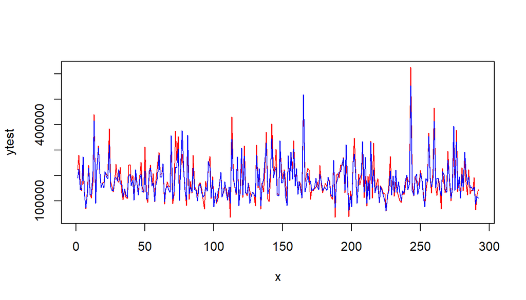

```r
x = 1:length(ytest)
plot(x, ytest, col = "red", type = "l")
lines(x, pred_y, col = "blue", type = "l")
legend(x = 1, y = 38,  legend = c("original test_y", "predicted test_y"),
       col = c("red", "blue"), box.lty = 1, cex = 0.8, lty = c(1, 1))
```

Inference:- From graph we can infer that almost actual and predicted values are similar

### Metrics

```r
mse = mean((ytest - pred_y)^2)
mae = caret::MAE(ytest, pred_y)
rmse = caret::RMSE(ytest, pred_y)

cat("MSE: ", mse, "MAE: ", mae, " RMSE: ", rmse)
```

```
## MSE:  926716351 MAE:  21759.98  RMSE:  30442.02
```

### R-Square

```r
sst <- sum((ytest - mean(ytest))^2)
sse <- sum((pred_y - ytest)^2)

rsquare_ridge <- 1-(sse/sst)
rsquare_ridge
```

```
## [1] 0.8537655
```

```r
rsquare_ridge_1 <- rsquare_ridge
```

### Adjusted R-Square

```r
n <- nrow(as.matrix(ytest))
p <- 10

arsquare_ridge <- (1-((1-rsquare_ridge)*(n-1)/(n-p-1)))
arsquare_ridge
```

```
## [1] 0.8485614
```

### ———— Model - 2 ——————

```r
df1 <- data.frame(df$SalePrice , df$OverallQual , df$GrLivArea  ,df$GarageCars,df$GarageArea ,df$TotalBsmtSF,df$X1stFlrSF ,df$FullBath ,df$YearBuilt  ,df$YearRemodAdd ,df$MasVnrArea)

head(df1)
```

```
##   df.SalePrice df.OverallQual df.GrLivArea df.GarageCars df.GarageArea
## 1       208500              7         1710             2           548
## 2       181500              6         1262             2           460
## 3       223500              7         1786             2           608
## 4       140000              7         1717             3           642
## 5       250000              8         2198             3           836
## 6       143000              5         1362             2           480
##   df.TotalBsmtSF df.X1stFlrSF df.FullBath df.YearBuilt df.YearRemodAdd
## 1            856          856           2         2003            2003
## 2           1262         1262           2         1976            1976
## 3            920          920           2         2001            2002
## 4            756          961           1         1915            1970
## 5           1145         1145           2         2000            2000
## 6            796          796           1         1993            1995
##   df.MasVnrArea
## 1           196
## 2             0
## 3           162
## 4             0
## 5           350
## 6             0
```

### Train/Set 80/20

```r
set.seed(123)
size <- floor(0.8* nrow(df1))
```

### Training Dataset

```r
train_ind <- sample(seq_len(nrow(df1)), size = size)
train <- df1[train_ind, ]
xtrain <- train[,c(2,3,4,5,6,7,8,9,10,11)]
ytrain <- train[,1]
```

### Testing Dataset

```r
test <- df1[-train_ind, ]
xtest <- test[,c(2,3,4,5,6,7,8,9,10,11)]
ytest <- test[,1]

xtrain <- as.matrix(xtrain)
ytrain <- as.matrix(ytrain)
xtest <- as.matrix(xtest)
ytest <- as.matrix(ytest)
```

### XGB

```r
xgb_train = xgb.DMatrix(data = xtrain, label = ytrain)
xgb_test = xgb.DMatrix(data = xtest, label = ytest)
```

```r
xgbc = xgboost(data = xgb_train, max.depth = 2, nrounds = 50)
print(xgbc)
```

```
## ##### xgb.Booster
## raw: 38.5 Kb
## call:
##   xgb.train(params = params, data = dtrain, nrounds = nrounds,
##     watchlist = watchlist, verbose = verbose, print_every_n = print_every_n,
##     early_stopping_rounds = early_stopping_rounds, maximize = maximize,
##     save_period = save_period, save_name = save_name, xgb_model = xgb_model,
##     callbacks = callbacks, max.depth = 2)
## params (as set within xgb.train):
##   max_depth = "2", validate_parameters = "1"
## xgb.attributes:
##   niter
## callbacks:
##   cb.print.evaluation(period = print_every_n)
##   cb.evaluation.log()
## # of features: 10
## niter: 50
## nfeatures : 10
## evaluation_log:
##     iter train_rmse
##        1  142797.33
##        2  105340.75
## ---
##       49   22815.56
##       50   22757.18
```

### Predicting Values

```r
pred_y = predict(xgbc, xgb_test)
```

### Actual vs Predicted Values

We’ll visualize y original test and y predicted data in a plot

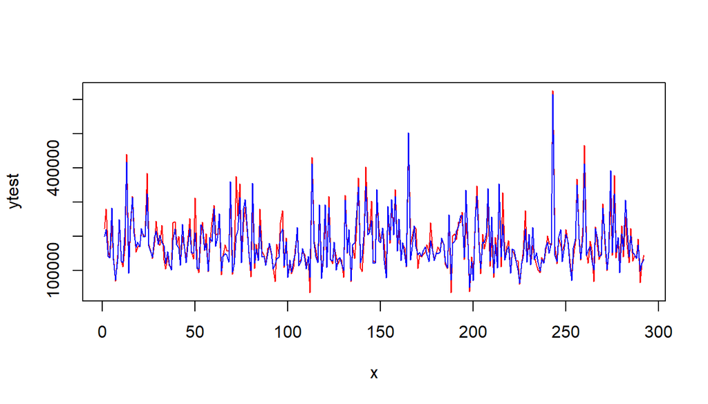

```r
x = 1:length(ytest)
plot(x, ytest, col = "red", type = "l")
lines(x, pred_y, col = "blue", type = "l")
legend(x = 1, y = 38,  legend = c("original test_y", "predicted test_y"),
       col = c("red", "blue"), box.lty = 1, cex = 0.8, lty = c(1, 1))
```

## Inference:-

### From graph we can infer that almost actual and predicted values are similar

### Metrics

```r
mse = mean((ytest - pred_y)^2)
mae = caret::MAE(ytest, pred_y)
rmse = caret::RMSE(ytest, pred_y)

cat("MSE: ", mse, "MAE: ", mae, " RMSE: ", rmse)
```

```
## MSE:  765700431 MAE:  19339.65  RMSE:  27671.29
```

### R-Square

```r
sst <- sum((ytest - mean(ytest))^2)
sse <- sum((pred_y - ytest)^2)

rsquare_ridge <- 1-(sse/sst)
rsquare_ridge
```

```
## [1] 0.8791736
```

```r
rsquare_ridge_1 <- rsquare_ridge
```

### Adjusted R-Square

```r
n <- nrow(as.matrix(ytest))
p <- 10

arsquare_ridge <- (1-((1-rsquare_ridge)*(n-1)/(n-p-1)))
arsquare_ridge
```

```
## [1] 0.8748737
```

### ———— Model - 3 ——————

```r
df1 <- data.frame(df$SalePrice , df$OverallQual , df$GrLivArea  ,df$GarageCars,df$GarageArea ,df$TotalBsmtSF,df$X1stFlrSF ,df$FullBath ,df$YearBuilt  ,df$YearRemodAdd ,df$MasVnrArea,df$TotRmsAbvGrd)

head(df1)
```

```
##   df.SalePrice df.OverallQual df.GrLivArea df.GarageCars df.GarageArea
## 1       208500              7         1710             2           548
## 2       181500              6         1262             2           460
## 3       223500              7         1786             2           608
## 4       140000              7         1717             3           642
## 5       250000              8         2198             3           836
## 6       143000              5         1362             2           480
##   df.TotalBsmtSF df.X1stFlrSF df.FullBath df.YearBuilt df.YearRemodAdd
## 1            856          856           2         2003            2003
## 2           1262         1262           2         1976            1976
## 3            920          920           2         2001            2002
## 4            756          961           1         1915            1970
## 5           1145         1145           2         2000            2000
## 6            796          796           1         1993            1995
##   df.MasVnrArea df.TotRmsAbvGrd
## 1           196               8
## 2             0               6
## 3           162               6
## 4             0               7
## 5           350               9
## 6             0               5
```

### Train/Set 80/20

```r
set.seed(123)
size <- floor(0.8* nrow(df1))
```

### Training Dataset

```r
train_ind <- sample(seq_len(nrow(df1)), size = size)
train <- df1[train_ind, ]
xtrain <- train[,c(2,3,4,5,6,7,8,9,10,11,12)]
ytrain <- train[,1]
```

### Testing Dataset

```r
test <- df1[-train_ind, ]
xtest <- test[,c(2,3,4,5,6,7,8,9,10,11,12)]
ytest <- test[,1]


xtrain <- as.matrix(xtrain)
ytrain <- as.matrix(ytrain)
xtest <- as.matrix(xtest)
ytest <- as.matrix(ytest)
```

### XGB

```r
xgb_train = xgb.DMatrix(data = xtrain, label = ytrain)
xgb_test = xgb.DMatrix(data = xtest, label = ytest)
```

```r
xgbc = xgboost(data = xgb_train, max.depth = 2, nrounds = 50)
print(xgbc)
```

```
## ##### xgb.Booster
## raw: 38.5 Kb
## call:
##   xgb.train(params = params, data = dtrain, nrounds = nrounds,
##     watchlist = watchlist, verbose = verbose, print_every_n = print_every_n,
##     early_stopping_rounds = early_stopping_rounds, maximize = maximize,
##     save_period = save_period, save_name = save_name, xgb_model = xgb_model,
##     callbacks = callbacks, max.depth = 2)
## params (as set within xgb.train):
##   max_depth = "2", validate_parameters = "1"
## xgb.attributes:
##   niter
## callbacks:
##   cb.print.evaluation(period = print_every_n)
##   cb.evaluation.log()
## # of features: 11
## niter: 50
## nfeatures : 11
## evaluation_log:
##     iter train_rmse
##        1  142797.33
##        2  105340.75
## ---
##       49   22764.13
##       50   22650.55
```

### Predicting Values

```r
pred_y = predict(xgbc, xgb_test)
```

### Actual vs Predicted Value

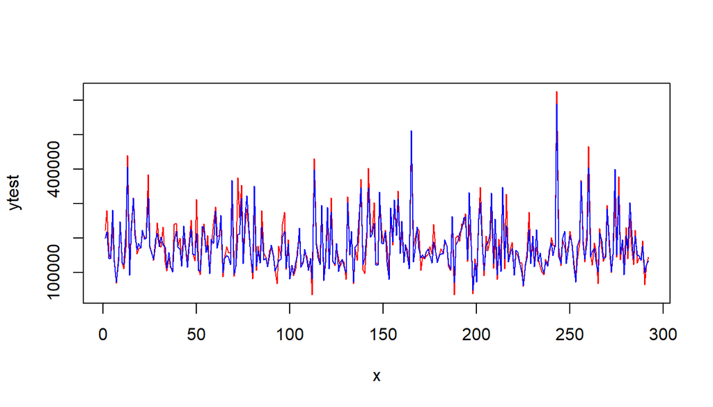

```r
x = 1:length(ytest)
plot(x, ytest, col = "red", type = "l")
lines(x, pred_y, col = "blue", type = "l")
legend(x = 1, y = 38,  legend = c("original test_y", "predicted test_y"),
       col = c("red", "blue"), box.lty = 1, cex = 0.8, lty = c(1, 1))
```

### Inference:- From graph we can infer that almost actual and predicted values are similar

### Metrics

```r
mse = mean((ytest - pred_y)^2)
mae = caret::MAE(ytest, pred_y)
rmse = caret::RMSE(ytest, pred_y)

cat("MSE: ", mse, "MAE: ", mae, " RMSE: ", rmse)
```

```
## MSE:  780458868 MAE:  19563.47  RMSE:  27936.69
```

### R-Square

```r
sst <- sum((ytest - mean(ytest))^2)
sse <- sum((pred_y - ytest)^2)

rsquare_ridge <- 1-(sse/sst)
rsquare_ridge
```

```
## [1] 0.8768447
```

```r
rsquare_ridge_1 <- rsquare_ridge
```

### Adjusted R-Square

```r
n <- nrow(as.matrix(ytest))
p <- 10

arsquare_ridge <- (1-((1-rsquare_ridge)*(n-1)/(n-p-1)))
arsquare_ridge
```

```
## [1] 0.872462
```

### Comparison Between Different Model for XGB

```r
model_x <- read.csv("D:\\COllege\\5th sem\\CSE3505\\Project\\Model_XGB.csv")
model_x
```

[output not shown]

## ##Inference of XGB on 3 Models:-

### Also in case of RMSE,MSE and MAE lower values are better.Thus compared to other three models model2 have lower RMSE,MSE,MAE values.